# STAT155-PROJECT3

Jenny Li, Xiang Li

2021/12/6

> **Introduction**

> Introduction to Topic

Sport, as an area receiving increased attention, responds as a result of increased awareness of people to their physical health, especially during the weird year 2020, where the pandemic changes the way of living as well as sport. Some sports benefit from it, some in alternative. For example, powerlifting is a strength sport that consists of three attempts at maximal weight on three lifts: squat, bench press, and deadlift. At the same time, a perfect self-training exercise while staying at home during the pandemic. When talking about powerlifting, one question always arises and is curious by the people is that “what actually would the weight of the lifters affect the weight they are lifting?”. In this report, we will build up a linear regression model including the bodyweight of the lifters, the total weight they can lift, and other possible factors to discuss this question.

> Research Questions

> **Data**

> Context

In this report, we’ll use data from the OpenPowerlifting database as of April 2019. OpenPowerlifting is creating a public-domain archive of power lifting history. Power lifting is a sport in which competitors compete to lift the most weight for their class in three separate barbell lifts: the Squat, Bench, and Dead lift. The data is represented by openpowerlifting.csv, which includes all information on the meets (competitions) as well as the competitors who attended those meets worldwide. This dataset tracks 2554800 entries for 668172 lifters from 39909 meets. All the data in the dataset are collected by a team of about eight power lifters from official results posted on federations’ websites. Find more information about the dataset and download the openpowerlifting.csv file on Kaggle: https://www.kaggle.com/open-powerlifting/powerlifting-database.

```r
# loading dataset
lifting <- read_csv (file = "openpowerlifting.csv")
```

> Cleaning

We first filter out all invalid data, NA, contained in the three variables– “TotalKg”, “BodyweightKg”, and “AgeClass”. We then create a histogram to visualize the distribution of the lifters’ age, which shows that their age is concentrated mainly around 18 to 44. Thus based on the visualization, we decided to only focus on the age class between “18-19”, “20-23”, “24-34”, “35-39”, and “40-44”, for not only narrowing down the dataset but also avoid the possible outliers.

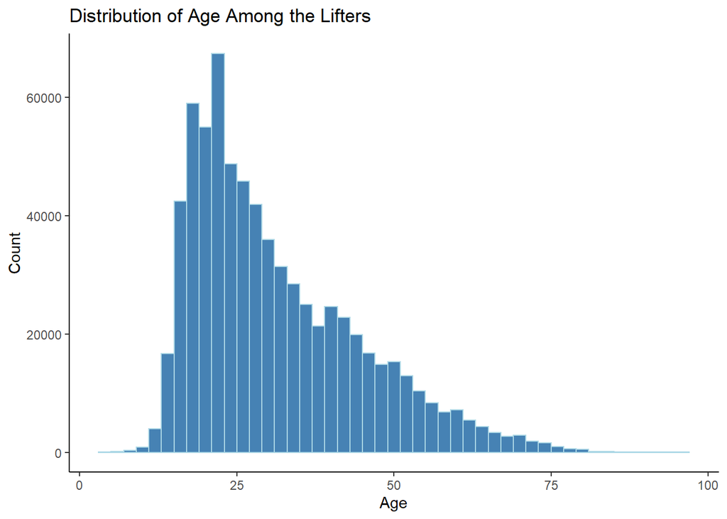

> **Linear Regression**

> Exploratory Data Analysis

The graphical summaries based on our dataset show us that the relationships between total weight lifting and bodyweight are very similar for females and males in each age class.

The fitted lines for males and females in each age group are almost parallel. In considering the relationship between total weight lifting and bodyweight for males and females, we see that males can always lift about 125 kg heavier than females when holding the age class and body weight constant. These relationships make sense because male lifters have a larger power than female lifters.

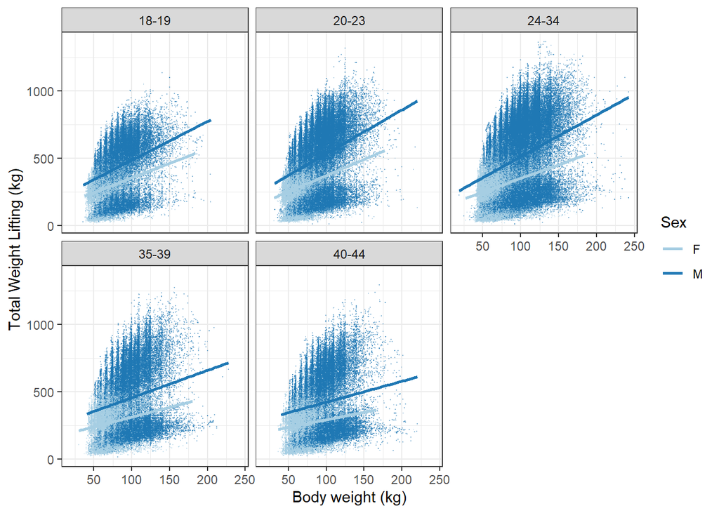

```
## # A tibble: 1 x 1
##   `cor(TotalKg, BodyweightKg)`
##                          <dbl>
## 1                        0.374
```

> Model Creation

> Research Question: What is the impact of the body weight of the lifters on the total weight they successfully lifted?

$$[ TotalWeightLifting | BodyWeight, AgeClass, Sex ] = \beta_0 + \beta_1 bodyweight + \beta_2 sexM + \beta_3 ageAgeClass20-23 + \beta_4 AgeClass24-34 + \beta_5 AgeClass35-39 + \beta_6 AgeClass40-44$$
We consider that bodyweight would directly predict whether the total weight lifted. At the same time, age class and sex might be confounders worth including since females and males in different age classes might directly affect the results. Other variables such as age, we consider as redundant toward the age class, and each weight lifting result is counted in the total weight lifting. A linear regression model is used to model the relationship between scalar results and single or multiple dependent and independent variables. We fit this dataset in linear regression because total weight lifting is a numerical outcome, which fits better in the linear regression model. As mentioned earlier, for accessibility, we choose three variables that influence the results more as the explanatory variables. We compare the model with and without age, and we figure out that the sigma for the one with age would be smaller, so we decided to include both age and sex in our model. Also, we decided not to include the interaction variable since the r-square between the two models does not show much difference. Within the age class, we choose the lifters that are between “18-19”, “20-23”, “24-34”, “35-39”, and “40-44” that contain the most data to analyze.

> Fitted Model

```
##   (Intercept)  BodyweightKg          SexM AgeClass20-23 AgeClass24-34
##      93.99834       2.62192     129.90265      36.95341      20.43743
## AgeClass35-39 AgeClass40-44
##     -23.92088     -51.10734
```

```
## # A tibble: 1 x 12
##   r.squared adj.r.squared sigma statistic p.value    df    logLik     AIC    BIC
##       <dbl>         <dbl> <dbl>     <dbl>   <dbl> <dbl>     <dbl>   <dbl>  <dbl>
## 1     0.209         0.209  200.    23654.       0     6 -3608359.  7.22e6 7.22e6
## # ... with 3 more variables: deviance <dbl>, df.residual <int>, nobs <int>
```

```
## # A tibble: 7 x 7
##   term          estimate std.error statistic   p.value conf.low conf.high
##   <chr>            <dbl>     <dbl>     <dbl>     <dbl>    <dbl>     <dbl>
## 1 (Intercept)      94.0     1.26        74.8 0            91.5      96.5
## 2 BodyweightKg      2.62    0.0138     190.  0             2.59      2.65
## 3 SexM            130.      0.711      183.  0           129.      131.
## 4 AgeClass20-23    37.0     0.989       37.4 6.25e-305    35.0      38.9
## 5 AgeClass24-34    20.4     0.926       22.1 6.13e-108    18.6      22.3
## 6 AgeClass35-39   -23.9     1.16       -20.6 7.84e- 94   -26.2     -21.6
## 7 AgeClass40-44   -51.1     1.17       -43.6 0           -53.4     -48.8
```

|  | Estimate | Lower 95% CI | Upper 95% CI | P-value |
| --- | --- | --- | --- | --- |
| (Intercept) | 93.9983 | 91.5343 | 96.4623 | 0 |
| BodyweightKg | 2.6219 | 2.5949 | 2.6490 | 0 |
| SexM | 129.9027 | 128.5089 | 131.2964 | 0 |
| AgeClass20-23 | 36.9534 | 35.0142 | 38.8926 | 0 |
| AgeClass24-34 | 20.4374 | 18.6229 | 22.2520 | 0 |
| AgeClass35-39 | -23.9209 | -26.2020 | -21.6398 | 0 |
| AgeClass40-44 | -51.1073 | -53.4035 | -48.8111 | 0 |

> Model Interpretation

#Estimates:

Based on our model, we estimate that the average total weight lifting for female lifters among those in the age class 18-19 in the 0kg body weight is 93.9983 kg. (Though this is not reasonable in reality, since it is impossible for a living individual to have 0kg body weight. Thus, the estimate of the intercept does not provide much information to us actually.)

Additionally, we estimate that the average total weight lifting for lifters in the age class 20-23 is 36.9534 kg higher than the total weight lifting for lifters in the age class 18-19 who are in the same body weight and gender.

Also, we estimate that the difference in the average total weight lifting when body weight increased by 1 kg is 2.6219 kg higher when holding other variables constant.

We estimate that the average total weight lifting for male lifters in the age class is 129.9027 kg higher than the total weight lifting for female lifters who are in the same body weight and age class.

The interpretations for the ageclass 24-34, ageclass 35-39, and ageclass 40-44 are similar to the interpretation for ageclass 20-23. However, for the lifters in ageclass 35-39, and ageclass 40-44, the average total weight lifting is smaller instead of the higher than the total weight lifting for lifters in the age class 18-19 who are in the same body weight and gender.

#95% confidence intervals:

We are 95% confident that, in the population, the total weight lifting by male lifters is between 128.5089 and 131.2964 kg greater than the total weight lifting by female lifters of the same age class and body weight.

We are 95% confident that, in the population, the total weight lifting by the lifters in the age class 20-23 is between 35.0142 and 38.8926 kg greater than the total weight lifting by the lifters in the age class 18-19 of the same gender and body weight.

The interpretations for the ageclass 24-34, ageclass 35-39, and ageclass 40-44 are similar to the interpretation for ageclass 20-23.

#P-value:

The null hypothesis (H0) for the intercept is saying that whether the lifter is in the age class 18-19 holding other conditions constant does not have an effect on total weight lifting.

Since the p-value for the intercept is zero, which is less than the threshold of 0.05, we do have sufficient evidence to reject the null hypothesis that gender does not have an effect on total weight lifting. We reject the null hypothesis and in favor that the age class 18-19 does have an effect on total weight lifting.

In addition, the null hypothesis (H0) for BodyweightKg is saying that bodyweight does not have an effect on total weight lifting, after accounting for the other variables– gender and age classes.

The alternative hypothesis (HA) for BodyweightKg, on the other hand, is saying that body weight has an effect on total weight lifting, after accounting for the other variables

Similar to the intercept, since the p-value for BodyweightKg is zero, which is less than the threshold of 0.05, we do have sufficient evidence to reject the null hypothesis –bodyweight does not have an effect on total weight lifting– and in favor of the alternative.

Moreover, the null hypothesis (H0) for SexM is saying that there is no relationship between the gender and total weight lifting, after accounting for other variables.

The p-value for SexM is also zero, which is less than the threshold of 0.05. Thus we do have sufficient evidence to reject the null hypothesis that gender does not have an effect on total weight lifting. We reject the null hypothesis in favor of that gender has an effect on total weight lifting.

The null hypothesis (H0) for AgeClass20-23 is saying that age class 20-23 does not have an effect on total weight lifting, after accounting for other variables.

The interpretations for the ageclass 24-34, ageclass 35-39, and ageclass 40-44 are similar to the interpretation for ageclass 20-23.

Thus, we have evidence to support that body weight, age, class, and gender each have a relationship with total weight lifting.

> Model Evaluation

The R-squared of the model (mod1) is 0.2090, which means that about 20.9% of the residuals are accounted for in the regression model.

Since the R-squared value for the model to predict total weight lifting is 20.9%, we can explain about 20.9% of the variation in the total weight lifting using this model with three variables. The adjusted R-squared is 0.209. Clearly, body weight, ageclass, and sex explain the minority variation in total weight lifting.

The residual standard error is the standard deviation of our residuals. The residual has a standard deviation of 200.1854, which means the average difference between the expected residuals from the mean. It turns out that the mean of our residuals will always be zero. So, our residual standard error gives us a sense of how tightly concentrated all of our residuals are around zero, which tells us how tightly concentrated our predictions are around the true values. This residual standard error is very large. A useful rule of thumb tells us that if our data are normally distributed, 95% of observations will fall within two standard deviations of the mean. Applying this rule to our residual standard error, we can say that our model predicts total weight lifting for most lifters within 400.37 kg.

```
## # A tibble: 537,104 x 10
##    TotalKg BodyweightKg Sex   AgeClass .fitted .resid      .hat .sigma   .cooksd
##      <dbl>        <dbl> <chr> <chr>      <dbl>  <dbl>     <dbl>  <dbl>     <dbl>
##  1   290           59.8 F     24-34       271.   18.8 0.0000100   200.   1.26e-8
##  2   332.          58.5 F     24-34       268.   64.7 0.0000101   200.   1.51e-7
##  3    32.5         55.4 F     40-44       188. -156.  0.0000235   200.   2.03e-6
##  4   310           60   F     20-23       288.   21.7 0.0000133   200.   2.25e-8
##  5   370           74   F     35-39       264.  106.  0.0000213   200.   8.53e-7
##  6   345           59.8 F     20-23       288.   57.3 0.0000133   200.   1.56e-7
##  7   370           80.4 F     35-39       281.   89.1 0.0000216   200.   6.10e-7
##  8   520          108   F     35-39       353.  167.  0.0000270   200.   2.67e-6
##  9   475           74.8 F     35-39       266.  209.  0.0000213   200.   3.32e-6
## 10   462.          82   F     24-34       329.  133.  0.0000104   200.   6.55e-7
## # ... with 537,094 more rows, and 1 more variable: .std.resid <dbl>
```

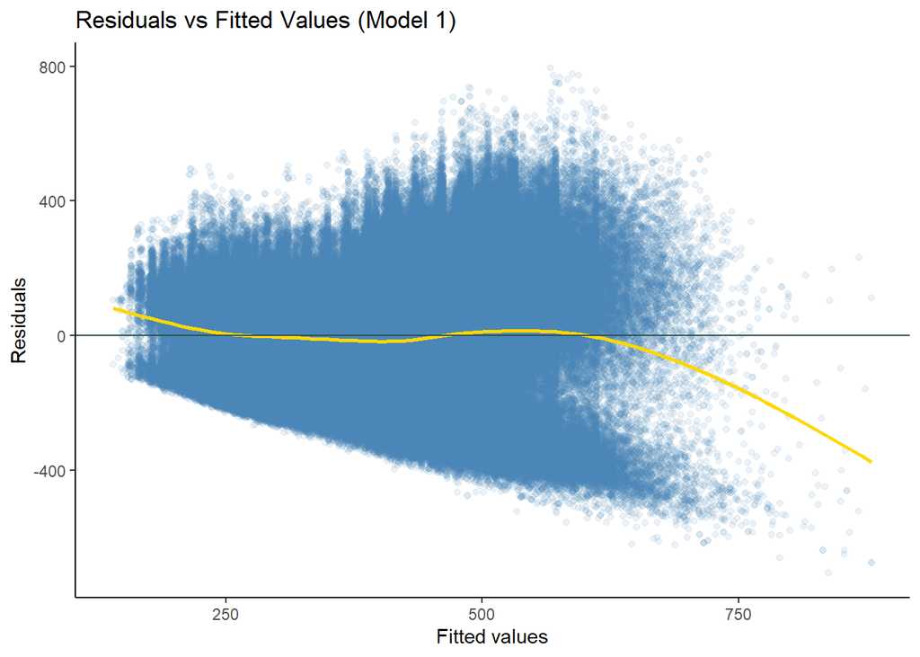

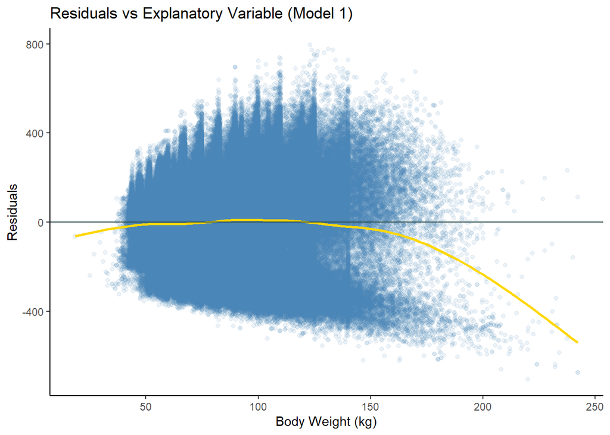

> **Conclusion**

> General Takeaways

> Limitation

This dataset was updated three years ago, which is a bit outdated. So, the data might not correctly represent the successful lifting rate impact by the age and equipment during recent times.

The potential benefits of such data might contribute to improving the training method of the lifters, since improving the total lifting weight is one of the most important goals for them.

Additionally, the database we are sampling from is originally selected from public resources. Therefore, it is possible to have a publicly available dataset.

However, due to some reasons, such as the missing data, our model could only explain the minor variation in total weight lifting as mentioned previously. Additionally, other variables, such as the equipment used by a lifter that might affect the outcome, have not been included in the model, which could decrease the model’s accuracy. We decided not to include an interaction term as well since the r-square between two models does not show much difference, though in general, the r-square with the one containing interaction terms is slightly larger.

> Appendix Works Cited

OpenPowerlifting. “Powerlifting Database.” Kaggle, April 25, 2019. https://www.kaggle.com/open-powerlifting/powerlifting-database.

> R Code

```r
library(readr)
library(dplyr)
library(ggplot2)
library(ggmosaic)
library(broom)
library(knitr)

# loading dataset
lifting <- read_csv (file = "openpowerlifting.csv")

# Filter data age and body weight
lifting1 <- lifting[!is.na(lifting$TotalKg), ]
lifting1 <- lifting1[!is.na(lifting1$BodyweightKg),]
lifting1 <- lifting1[!is.na(lifting1$AgeClass),]

# Distribution of age
lifting1%>%
  ggplot(aes(x=Age))+
  geom_histogram(binwidth = 2,color='lightblue', fill='steelblue')+
  ylab('Count') +
  xlab('Age') +
  theme_classic() +
  ggtitle('Distribution of Age Among the Lifters')

# Filter data age
lifting1 <- lifting1 %>%
  filter(AgeClass %in% c("18-19", "20-23", "24-34", "35-39", "40-44"))

# plot graph
lifting1 %>%
  ggplot(aes(x = BodyweightKg, y = TotalKg, color = Sex)) +
  geom_point(alpha = .5, pch = ".") +
  geom_smooth(method = 'lm', se = FALSE) +
  facet_wrap(~ AgeClass) +
  labs(x = "Body weight (kg)", y = "Total Weight Lifting (kg)") +
  theme(plot.title = element_text(hjust = 0.5, face = "bold", size = 14),
        legend.position = "none") +
  scale_color_brewer(palette = "Paired") +
  theme_bw()

# numerical summary
lifting1 %>%
  summarize(cor(TotalKg, BodyweightKg))

# fitted model
mod1 <- lm(with(TotalKg ~ BodyweightKg + Sex + AgeClass, data = lifting1))
coef(mod1)
glance(mod1)

# mod2 <- lm(with(TotalKg ~ BodyweightKg + Sex + AgeClass+BodyweightKg:Sex, data = lifting1))
# coef(mod2)
# glance(mod2)

# creating table for fitted model
mytab <- as.table(cbind(c(93.9983,2.6219,129.9027,36.9534,20.4374, -23.9209, -51.1073), c(91.5343,2.5949,128.5089,35.0142,18.6229,-26.2020,-53.4035), c(96.4623, 2.6490,131.2964,38.8926,22.2520,-21.6398, -48.8111), c(0.0000,0.0000,0.0000,6.254701e-305,6.131519e-108,7.843960e-94,0.0000)))
colnames(mytab) <- c("Estimate", "Lower 95% CI", "Upper 95% CI", "P-value")
rownames(mytab) <- c("(Intercept)", " BodyweightKg", " SexM", "AgeClass20-23", "AgeClass24-34", "AgeClass35-39", "AgeClass40-44")
kable(mytab)

# residual plot
augment(mod1)
augment(mod1) %>%
    ggplot(aes(x = .fitted, y = .resid)) +
    geom_point(color = "steelblue", alpha = 1/10) +
    geom_smooth(se = FALSE, color = "gold") +
    geom_hline(yintercept = 0, color = "darkslategray") +
    theme_classic() +
    labs(x = "Fitted values", y = "Residuals", title = 'Residuals vs Fitted Values (Model 1)')

augment(mod1) %>%
  ggplot(aes(y = .resid, x = BodyweightKg)) +
  geom_point(color = "steelblue", alpha = 1/10) +
  geom_smooth(se = FALSE, color = "gold") +
  geom_hline(yintercept = 0, color = "darkslategray") +
  labs(x = 'Body Weight (kg)', y = 'Residuals', title = 'Residuals vs Explanatory Variable (Model 1)') +
  theme_classic()
```